# Ahmedabad’s Public Libraries

Reach, transit, and a declining public

Author

Right 2 Read Campaign

Published

June 14, 2026

## Abstract

A public library is only public if people can reach it and use it. This paper asks whether Ahmedabad’s municipal library system — the Ahmedabad Public Library / M.J. Library Network — meets that standard, against three tests a city library should pass: can residents reach it on foot; does public transit extend that reach to the periphery; and, given reach, do people actually use it. We answer with the system’s own decade of disclosures and the city’s ward, walking, and transit geography. The Toronto Public Library appears only as a background yardstick for what a working municipal system discloses and reaches.

The findings are not reassuring. The walk-access proxy is uneven: short in the central wards where the historic branches sit, 40 to 80 minutes on the populous industrial periphery. The Metro and Janmarg/AJL BRTS network already runs through every one of those worst-served wards, yet only 60 of 83 libraries sit within 500 m of rapid transit — a siting failure, not a transit gap. And use is not low and stable; it is falling. Annual circulation dropped 55 percent from its 2017-18 peak to 96,491 in 2025-26; new annual members fell 84 percent to about 500 a year; the reported 26,834-member total holds only because 95 percent of it is a lifetime roll that never expires. A budget that spends 61.7 percent on establishment and 1.4 percent on books explains the starved collection behind the decline. Toronto, far better resourced, lends roughly 735 times more per resident — a gap several times larger than even the per-resident spending gap, so money alone does not explain Ahmedabad’s retreat.

## The case: why a city library must be reachable

Before measuring Ahmedabad, we should say plainly what a public library is for, and why its location matters. Three claims set the standard the rest of the paper tests.

**A public library is civic infrastructure, not a book warehouse.** Its purpose is use. Ranganathan’s laws are blunt about it: books are for use, every reader should find their book and every book its reader, and the reader’s time should be saved (Ranganathan 1931); the IFLA-UNESCO manifesto frames the public library as a local institution for education, information, and democratic life (International Federation of Library Associations and Institutions and UNESCO 2022). Contemporary scholarship reads it as social and intellectual infrastructure — a low-threshold public place that anchors everyday civic life and should be provisioned and judged like other urban systems, not treated as a soft amenity (Mattern 2014; Klinenberg 2018). In India the same institution has been named a bedrock of democratic and anti-caste life (Liang and Gupta 2024) and just as routinely left to decay by the states that own it (Chitralekha 2014; Pyati 2009). For a campaign for the right to read, the library is the public’s standing claim on knowledge; whether people can actually reach and use it is the whole question.

**A library is public only if it is reachable on foot.** Most users of an Indian city library do not arrive by car; they walk, and the residents who depend most on a nearby branch — children, students, women, older and poorer people — are exactly those least able to travel far. Use falls with distance: the spatial-access literature treats proximity, travel time, and distance decay as central, not incidental (Penchansky and Thomas 1981; Luo and Wang 2003). This is why cities now plan deliberately for short-walk access to everyday public facilities. The “15-minute city” and, since 2016, China’s “15-minute community life circle,” first issued in Shanghai, require libraries and other daily services to fall within a short walk — and then audit that coverage as a governance metric (Yang and Qian 2024; Ma et al. 2023). Walkability is not an amenity layered on top of a library; it is the precondition for the library being public at all.

**Where walking ends, buses and the metro must begin.** No single branch can be a short walk from seven million people. A citywide system therefore depends on public transit to extend each branch’s reach — and on libraries being sited on the transit network to begin with. The IFLA service guidelines are explicit that service points belong where people already converge, with branch, deposit, and mobile service tiered outward so that everyone in the area is reached (IFLA Public Library Section 2010). Without transit, a “citywide” library is in practice a library for the central and the car-owning; with it, the periphery can be served. But a nearby stop is not yet access: the first- and last-mile stretches, the waiting and the transfers, are where journeys break down, especially for women (Roy et al. 2024). Buses and the metro matter because they are how a library reaches the residents who most need it and can least afford the trip.

This is not a parochial or a Northern standard. Reachable, well-served neighbourhoods are what the major quantitative livability frameworks measure and reward — the Economist Intelligence Unit’s liveability ranking, the Mercer quality-of-living index, the Social Progress Index, and the wider field of more than 150 city-benchmarking efforts (Wolfmayr 2024; Kitchin et al. 2015) — and the cities that consistently top them (Vienna, Vancouver, Melbourne, Geneva) are precisely those with dense, walkable, transit-served public provision. The same coverage logic is now codified across the Global South, most explicitly in China’s 15-minute community life circle, which sets pedestrian-distance coverage of daily public facilities as a measured governance target (Yang and Qian 2024; Ma et al. 2023), and it runs through Southern urban practice more broadly, where reliable access to shared services — not the spectacle of the flagship — is the test of a functioning city (Bhan 2019; *The Routledge Companion to Planning in the Global South* 2017). We borrow these frameworks’ coverage logic, not their league tables: city rankings can be naive and politically loaded, treating the city as a scoreboard rather than a public (Kitchin et al. 2015). The question is not where Ahmedabad places, but whether its residents can reach and use the library their taxes already fund.

Indian researchers have documented these same access deficits across the country’s cities. Transport policy has expanded mass transit while keeping equity out of its planning framework (Verma et al. 2021); the street has been progressively captured by the private automobile at the walker’s expense (Gopakumar 2020); and public open space is shrinking and unequally shared, with land-cover analysis of India’s ten largest cities showing the urban commons fragmenting over fifteen years (Agarwal et al. 2023). The contest over India’s “open space” and “public place” is itself long-standing (Chakrabarty 1991). The public library is one more public amenity caught in this pattern — provided in form, hard to reach in use.

Together these set the three tests for Ahmedabad: can people reach the library on foot; does the transit network extend that reach to the periphery; and, given reach, do they use it. The measurement that follows serves those questions, not the reverse.

## Measurement frame

To test those claims we need a consistent set of indicators. We use the IFLA Library Map of the World grammar, built on ISO 2789 definitions: service points, registered users, visits, physical and digital loans, staff, internet access, and collections, all comparable per population (International Federation of Library Associations and Institutions 2026; ISO 2789 2022). ISO 11620 adds the performance question — not how much a library owns, but how well its resources convert into use (ISO 11620 2023). A branch count alone can make a weak system look healthy; “access,” likewise, can be merely nominal — a library can be available on paper and still go unused, or remain exclusionary in practice (Mickiewicz 2016).

Access is not distance. A defensible accessibility model needs demand origins, supply capacity, travel time, catchments, and distance decay, not nearest-facility distance alone (Guagliardo 2004; Luo and Wang 2003; Luo and Qi 2009); even the nearest-facility assumption is only an approximation of how people travel (Nisar et al. 2018). We therefore treat Ahmedabad’s ward-centroid walk model as a first diagnostic, not a settled accessibility finding. Five rules carry into the analysis: normalize by population; separate service points from effective capacity; treat public funding as an input, not a result; read user fees as a possible barrier even when fiscally minor; and keep spatial access as a proxy until travel-time routing is built.

## Data and methods

The unit of analysis is Ahmedabad’s municipal public-library system, the **Ahmedabad Public Library / M.J. Library Network**; “M.J. Library” denotes only the flagship branch. We read it against a single external benchmark — the Toronto Public Library — used only as a yardstick for what a functioning municipal system discloses and reaches, not as a fairness comparison between a wealthy global-North city and a mid-budget Indian one.

For Ahmedabad we use the M.J. Network’s annual proactive (RTI) disclosures, 2015-16 to 2025-26, for collections, membership, and circulation, and its annual budget disclosures for finance; ward population and the Metro / Janmarg-AJL BRTS / AMTS layers come from the campaign’s Ahmedabad data. For Toronto we use the city’s open-data branch file, the 2024 published key facts, and the 2026 finance page. Counts are converted to per-resident or per-100,000-resident rates against a fixed denominator for each city — Ahmedabad 7,078,533 (2020 ward population), Toronto 2,794,356 (2021 census) — stated so readers can rescale.

We separate matched from partial indicators: a matched indicator is reported by both on a comparable basis; a partial one is reported by only one, or on bases too different to divide, and is kept to mark a gap, not to form a ratio. Where a ratio would pair non-comparable objects we say “not comparable” rather than print a number. The Ahmedabad spatial-access measure is a ward-centroid, population-weighted walk-time proxy over 48 wards and 83 geocoded locations; it is not scheduled-transit routing and understates within-ward inequality. All figures are produced from these source tables by `scripts/make_library_paper_figures.py`; the full source inventory is in the appendix.

## Ahmedabad I — can people reach it on foot?

The ward-level proxy does not show a total desert, but it is sharply uneven.

| Ahmedabad access metric | Value |
| --- | --- |
| Ward origins | 48 |
| Library locations | 83 |
| Median walk time to nearest library | 14.5 minutes |
| 75th percentile walk time | 31.6 minutes |
| 90th percentile walk time | 53.4 minutes |
| Population within 10 minutes walking | 41.9% |
| Population within 30 minutes walking | 68.5% |

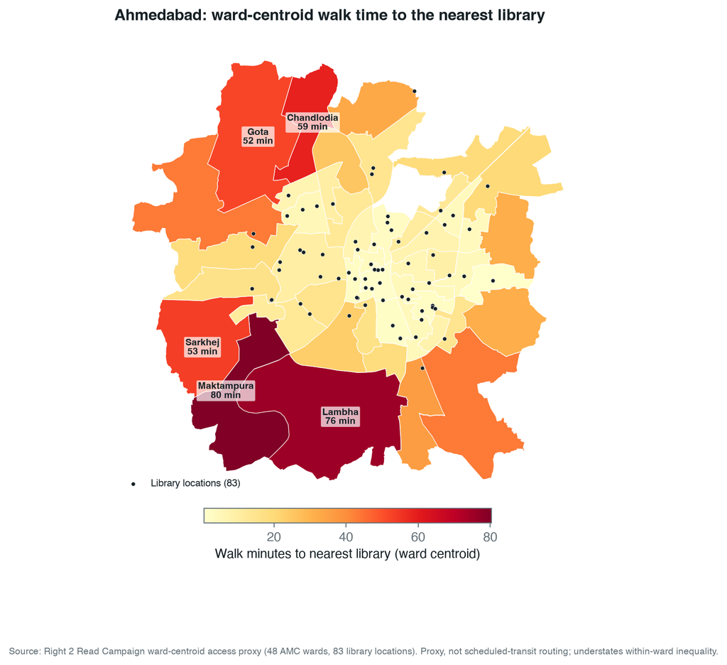

Figure 1: Ward-centroid walk time to the nearest of 83 library locations, 48 AMC wards. Central wards are well covered; the populous industrial periphery is not.

This is a ward-centroid model, not scheduled-transit routing; it understates within-ward inequality and cannot answer the median-resident-by-actual-travel-time question. Still, it points two ways at once. Spatial absence is real on the periphery — and, as the use figures below show, even the well-covered central wards generate little disclosed use, so distance is only part of the story.

## Ahmedabad II — does transit extend the reach?

Walking is not the only way to a library, so we set the city’s three public transit modes — the Metro, the Janmarg/AJL bus-rapid-transit (BRTS) corridors, and the AMTS bus network — against the library map (Figure 2). The access model also carries a scheduled-transit travel time, but it is a crude proxy that adds a fixed wait and transfer penalty; in it the bus never beats walking to a library in any of the 48 wards, which is an artefact of the proxy, not a finding, so we do not report transit travel times. What the network geometry shows, with no routing assumption, is a siting problem.

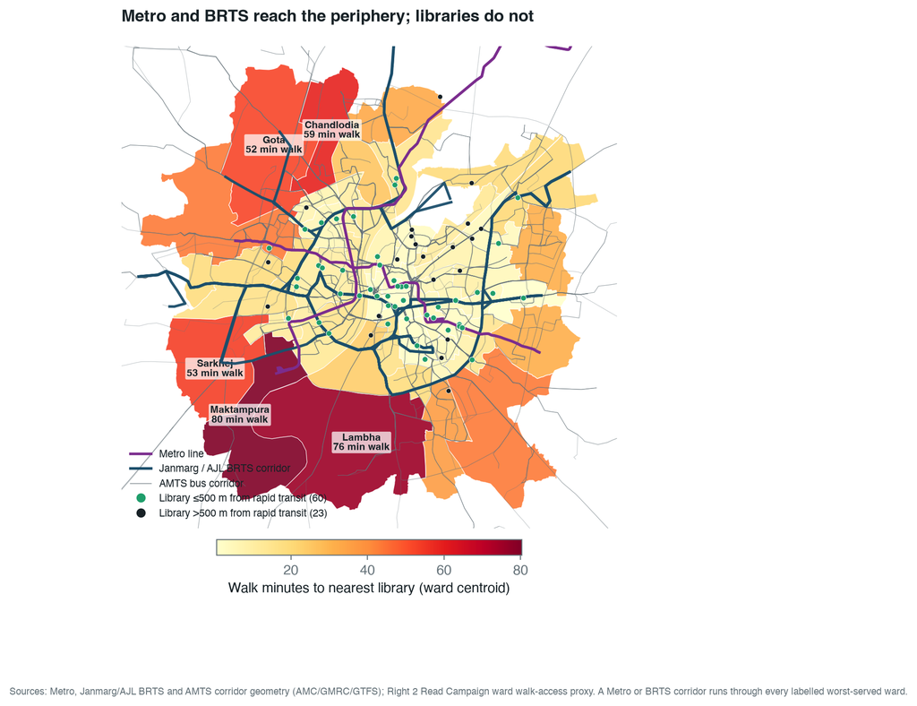

Figure 2: Walk time to the nearest library (ward fill) against the Metro, Janmarg/AJL BRTS, and AMTS networks. A Metro or BRTS corridor runs through every labelled worst-served ward, yet 23 of 83 libraries are not near rapid transit and the peripheral wards on the lines have no library within reach.

The rapid-transit network already reaches the underserved periphery. A Metro or BRTS corridor runs through every one of the worst-served wards — Maktampura, Lambha, Sarkhej, Gota, Ramol Hathijan, Vatva, Thaltej — the same wards 40 to 80 minutes’ walk from a library. The libraries are what is missing: only 60 of 83 sit within 500 m of a Metro or BRTS corridor, and 23 are not near rapid transit at all. Almost every library is near an AMTS bus stop (74 of 83 within 300 m), so the periphery is not unreachable. The public-library network was simply not built along the high-capacity lines that already serve these wards.

This is the cheapest problem in the paper to fix. Putting branch service — even small reading rooms or extension counters — on the Metro and BRTS corridors that already pass through Lambha, Maktampura, Sarkhej, Vatva, and Ramol Hathijan would convert existing transit investment into library access without waiting for new roads or new routing. It is exactly the coverage discipline that the 15-minute-city and life-circle plans elsewhere make a standing governance metric (Yang and Qian 2024; Ma et al. 2023); the deficit those audits report — the suburban periphery — is the same one Ahmedabad has.

## Ahmedabad III — given reach, do people use it?

Reach without use is the deeper failure, and here Ahmedabad’s own disclosures are damning. The single-year picture is already weak:

| Ahmedabad Public Library / M.J. Library Network, 2025-26 | Value |
| --- | --- |
| Collection items | 811,093 |
| New additions | 4,859 |
| Registered network members | 26,834 |
| Annual members | 505 |
| Lifetime members | 25,574 |
| Annual circulation | 96,491 |
| Membership penetration | 0.379% |
| Residents per registered member | 263.8 |

Nominal proximity is not becoming use. A city can have many branch points and still fail to produce demand if hours, staffing, discoverability, borrowing rules, materials, reading-room access, transport connection, or trust are weak. And the single year understates the problem: read as a 2015-16 to 2025-26 series, the network’s own disclosures show use falling, not holding steady (Figure 3).

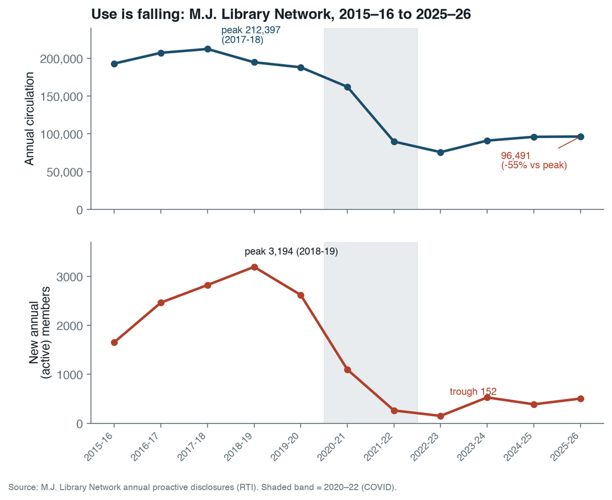

Figure 3: Annual circulation and new active membership, M.J. Library Network, 2015-16 to 2025-26. Circulation peaks in 2017-18 and settles near half that level; new annual members fall by 84 percent from their 2018-19 peak.

The underlying values:

| Year | Circulation | Annual (active) members | Lifetime members |
| --- | --- | --- | --- |
| 2015-16 | 193,138 | 1,655 | 19,109 |
| 2016-17 | 207,360 | 2,465 | 20,907 |
| 2017-18 | **212,397** | 2,823 | 21,496 |
| 2018-19 | 194,822 | **3,194** | 22,114 |
| 2019-20 | 188,175 | 2,620 | 24,575 |
| 2020-21 | 162,323 | 1,098 | 23,146 |
| 2021-22 | 89,846 | 263 | 23,447 |
| 2022-23 | 75,814 | **152** | 23,544 |
| 2023-24 | 91,139 | 529 | 23,949 |
| 2024-25 | 96,115 | 389 | 25,332 |
| 2025-26 | 96,491 | 505 | 25,574 |

Three movements run through this table. First, circulation collapsed and did not recover: it peaked at 212,397 in 2017-18 and stands at 96,491 in 2025-26, a fall of about 55 percent that begins before the pandemic, accelerates sharply in 2021-22, and then flattens at a new floor near half the former level. This is a step-down, not a dip. Second, the inflow of new active users almost stopped: annual members peaked at 3,194 in 2018-19, fell to 152 in 2022-23, and have only partly recovered to 505 — an 84 percent fall from the peak. A system that signs up roughly 500 active members a year in a city of seven million is not recruiting the public; it is being visited by a residual base. Third, the headline member total is an accounting artefact: lifetime members grew from 19,109 to 25,574 across the decade, because a lifetime member is never removed from the roll, and now make up about 95 percent of the total (Figure 4).

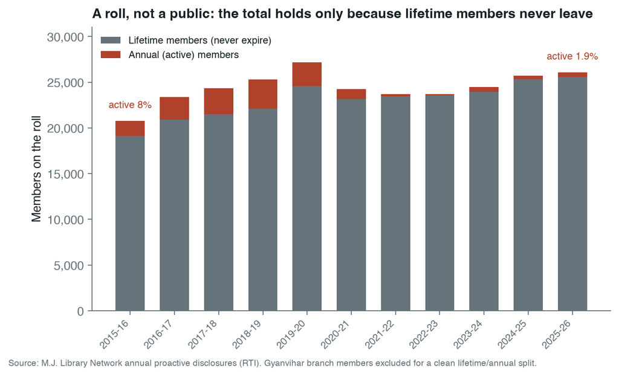

Figure 4: Members on the roll, by type. The total is roughly flat because lifetime members accumulate and never leave, while the active (annual) share falls from 8 percent to under 2 percent.

The “26,834 members” figure is stable not because the system is healthy but because a permanent roll masks the fall in living membership. Naming the system after its nineteenth-century flagship is not only a labelling problem; it describes what the institution has functionally remained — a legacy subscription library whose active public has been shrinking for years.

## Ahmedabad IV — is it funded to do the job?

The system is overwhelmingly public in fiscal form. In 2025-26 it reports a total budget of Rs 22.7675 crore, an AMC grant of Rs 21.9255 crore (96.30 percent), and library income of Rs 0.8420 crore (3.70 percent). User fees are therefore not the operating model; they function as an administrative gate inside an already publicly funded system. The policy question is not how to raise more fees — removing fee barriers would cost little against the grant and could help membership — but how a 96 percent-funded system converts so little subsidy into use.

The composition of that budget is the answer. It spends Rs 14.0415 crore on establishment and payroll and Rs 0.3275 crore on reading material — 61.7 percent and 1.4 percent of the total, a ratio of about 43 to 1 (Figure 5).

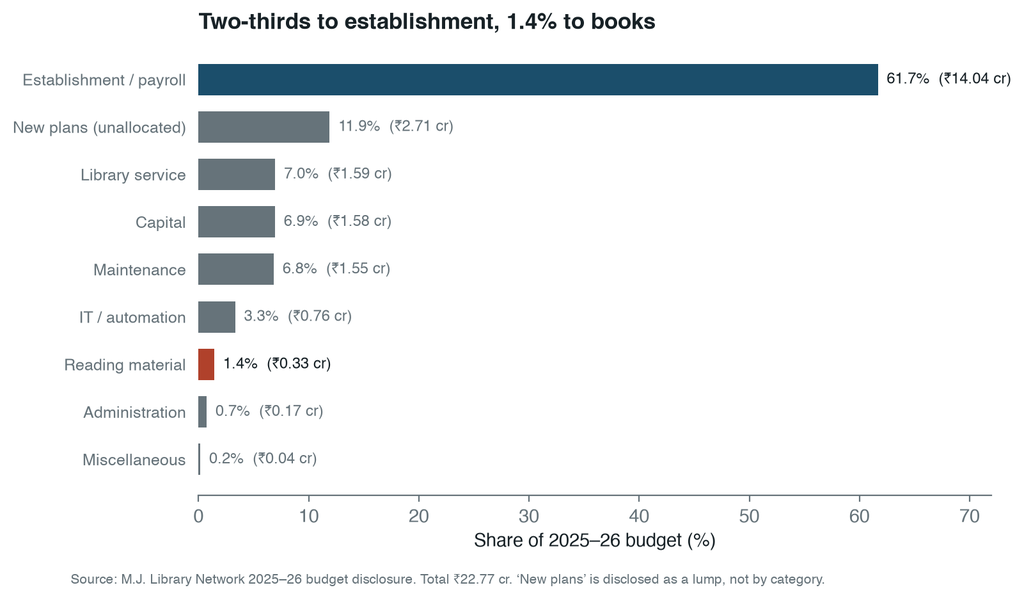

Figure 5: Ahmedabad Public Library / M.J. Library Network, 2025-26 budget by category. Establishment and payroll take 61.7 percent; reading material takes 1.4 percent. Total budget Rs 22.77 crore.

A budget that puts nearly two-thirds into establishment and under two percent into books is funding the institution’s continuity, not its collection. This is the fiscal counterpart of the membership finding: the system is preserved as a public establishment while the reading service it exists to deliver is starved. The decline in circulation is not mysterious if the public meets thin, slowly renewed shelves. For scale, a working municipal system spends far more on materials — Toronto’s 2026 library-materials line is 7.8 percent of expenditure, more than five times Ahmedabad’s share.

## Toronto, briefly: a background yardstick

Toronto is not the subject of this paper; it is a reference for what a functioning municipal library discloses and reaches. Its 2024 facts: 100 branches plus two bookmobiles, about 2.0 million sq ft of branch space, at least 10.5 million collection items, 13.4 million branch visits, 28 million borrowings, and 235,270 new card registrations, for a 2.79 million-resident base. On shared, population-normalized indicators:

| Indicator | Ahmedabad | Toronto | Toronto/Ahmedabad | Comparability |
| --- | --- | --- | --- | --- |
| Service points per 100,000 residents | 1.173 | 3.650 | 3.11x | High |
| Collection items per 1,000 residents | 114.6 | 3,758 | 32.79x | Medium |
| Registered member share of residents | 0.379% | not normalized |  | Partial |
| Annual member/card registration flow per 100,000 residents | 7.134 | 8,419 | not comparable | Partial |
| Borrowings/circulation per resident | 0.014 | 10.02 | 735.08x | Medium |
| Branch visits per resident | not disclosed | 4.795 |  | Partial |
| Median walk time to nearest library | 14.5 minutes | not computed |  | Partial |
| Reading/materials share of operating budget | 1.438% | 7.797% | 5.42x | Medium |

Toronto is denser (3.1× the service-point density), deeper (about 33× the collection per resident), and far more used (about 735× the borrowing per resident). One row is deliberately left without a ratio: Ahmedabad’s “annual members” is a membership tier, not a count of new users, while Toronto’s “new card registrations” is a genuine new-user inflow — different objects that should not be divided.

The tempting reading is that a rich city simply outspends a poor one. It does not survive the arithmetic. Per resident, Ahmedabad’s budget is about Rs 32 and Toronto’s about CAD 106; at a nominal CAD 1 ≈ Rs 60 — an explicit, replaceable assumption, not a sourced rate — Toronto spends on the order of 200 times more per resident, yet borrows about 735 times more. The use gap is several times wider than even the nominal spending gap, and purchasing-power adjustment, which narrows the money gap, widens the unexplained remainder. Money is not the explanation. A system spending two-thirds of its budget on establishment and under two percent on books, signing up about 500 active members a year, would under-perform its funding at any exchange rate.

## What Ahmedabad should do

The first conclusion is to treat the system as a citywide public-library network, not the M.J. flagship plus scattered assets. Governance follows the object named: if the object is the flagship, attention stays on a historic institution; if it is the city network, the questions become coverage, reach, use, renewal, hours, staffing, and accountability across all wards.

The second is to site for reach. The Metro and BRTS corridors already pass through the worst-served wards; branch service, reading rooms, or extension counters on those corridors would turn existing transit into library access at low cost. New service points should follow the IFLA rule — where people already converge — and be tiered, with mobile and deposit service reaching beyond the fixed branches (IFLA Public Library Section 2010).

The third is to fund the service, not just the establishment. An establishment share above 60 percent against a materials share of 1.4 percent cannot produce use; the mix must shift toward materials, hours, and branch staffing. The fourth follows from the decade series: the metric that matters is not the reported member total, which the lifetime roll will keep flattering, but the annual inflow of active members and annual circulation — both already disclosed, both falling. A credible target is stated against those two series, and the question is whether the system is managed to its use indicators or only to its grant.

## Data gaps and next work

The present Ahmedabad disclosure still lacks several IFLA-style fields: physical visits; e-book and audiobook loans; downloads and digital-resource use; full-time staff; volunteers; internet-access points; and branch hours and reading-seat capacity by location. Closing them turns a building list into a service system. Two extensions would do the most: a branch-capacity schema for Ahmedabad (square footage, seats, hours, staff, per-branch collection, digital access, program facilities), so a location count becomes a measure of capacity; and a capacity-aware, transit-routed access model that replaces the ward-centroid walk proxy with real Metro/BRTS/AMTS and walk routing from population origins.

## Conclusion

Ahmedabad’s public-library system fails the three tests a city library should pass. Reach is uneven — short in the centre, 40 to 80 minutes on the periphery. The transit network that could close that gap already runs through the underserved wards, but the libraries were not sited on it. And use, the point of the whole enterprise, is not low and stable but falling: circulation down about 55 percent over a decade, active membership down about 84 percent, a member total propped up only by a lifetime roll. A budget that spends 61.7 percent on establishment and 1.4 percent on books explains the starved collection behind that decline. Toronto, used only as a yardstick, shows the distance: several times the density and depth and roughly 735 times the borrowing per resident — a gap money alone cannot explain.

The practical target is not a better flagship story. It is a citywide standard: branches that are reachable on foot and by transit, open, stocked, staffed, free or near-free to join, sited where people already are, and measured every year on the use indicators the system already collects.

## Sources and reproducibility

**Ahmedabad.** Operations, membership, collection, and finance figures come from the M.J. Library Network’s annual proactive disclosures (RTI) and budget tables, 2015-16 to 2025-26, published on the official M.J. Library website (M.J. Library 2026). Ward boundaries and population are from the Ahmedabad Municipal Corporation; the Metro, Janmarg/AJL BRTS, and AMTS network geometry is from official AMC/GMRC/GTFS sources. The walk-access proxy is computed over 48 AMC wards and 83 geocoded library locations.

**Toronto (background yardstick).** Branch locations and counts are from Toronto Open Data’s Library Branch General Information package (City of Toronto Open Data 2026); visits, borrowing, collection, and registration figures from Toronto Public Library’s 2024 published key facts (Toronto Public Library 2026a); finance from the 2026 library budget (Toronto Public Library 2026b).

**Standards.** Indicators follow the IFLA Library Map of the World grammar and ISO 2789 / ISO 11620 definitions (International Federation of Library Associations and Institutions 2026; ISO 2789 2022, ISO 11620 2023); the normative and siting frame draws on the IFLA-UNESCO Public Library Manifesto (2022) and the IFLA Public Library Service Guidelines (2010) (International Federation of Library Associations and Institutions and UNESCO 2022; IFLA Public Library Section 2010).

The IFLA frame is used as an indicator grammar, not a claim that every field has a single universal target: matched indicators are separated from partial ones, and where a system does not disclose a metric the absence is kept as a data gap rather than inferred. All charts and maps are reproducible from the source tables by the figure script in the project repository.

## References

Agarwal, Shivani, Preeti Rao, and Harini Nagendra. 2023. “Fifteen Years of Fragmentation and Land Cover Change in India’s Ten Largest Cities: A Google Earth Engine Analysis.” *Cities and the Environment*.

Bhan, Gautam. 2019. “Notes on a Southern Urban Practice.” *Environment and Urbanization*.

Chakrabarty, Dipesh. 1991. “Open Space/Public Place: Garbage, Modernity and India.” *South Asia: Journal of South Asian Studies*.

Chitralekha. 2014. “Which Way for Public Libraries in India?” *Economic and Political Weekly*.

City of Toronto Open Data. 2026. *Library Branch General Information*. https://open.toronto.ca/dataset/library-branch-general-information/.

Gopakumar, Govind. 2020. *Installing Automobility: Emerging Politics of Mobility and Streets in Indian Cities*. The MIT Press.

Guagliardo, Mark F. 2004. “Spatial Accessibility of Primary Care: Concepts, Methods and Challenges.” *International Journal of Health Geographics* 3 (3). https://doi.org/10.1186/1476-072X-3-3.

IFLA Public Library Section. 2010. *IFLA Public Library Service Guidelines*. 2nd, completely revised. De Gruyter Saur.

International Federation of Library Associations and Institutions. 2026. *About Library Data: Library Map of the World*. https://librarymap.ifla.org/about-library-data.

International Federation of Library Associations and Institutions, and UNESCO. 2022. *The IFLA-UNESCO Public Library Manifesto 2022*. https://repository.ifla.org/handle/20.500.14598/2006.

ISO 11620: Information and Documentation – Library Performance Indicators (2023).

ISO 2789: Information and Documentation – International Library Statistics (2022).

Kitchin, Rob, Tracey P. Lauriault, and Gavin McArdle. 2015. “Knowing and Governing Cities Through Urban Indicators, City Benchmarking and Real-Time Dashboards.” *Regional Studies, Regional Science*.

Klinenberg, Eric. 2018. *Palaces for the People: How Social Infrastructure Can Help Fight Inequality, Polarization, and the Decline of Civic Life*. Crown.

Liang, Lawrence, and Aditya Gupta. 2024. *The Public Library Movement in India: Bedrock of Democracy and Freedom*.

Luo, Wei, and Yi Qi. 2009. “An Enhanced Two-Step Floating Catchment Area Method for Measuring Spatial Accessibility to Primary Care Physicians.” *Health & Place* 15 (4): 1100–1107. https://doi.org/10.1016/j.healthplace.2009.06.002.

Luo, Wei, and Fahui Wang. 2003. “Measures of Spatial Accessibility to Health Care in a GIS Environment: Synthesis and a Case Study in the Chicago Region.” *Environment and Planning B: Planning and Design* 30 (6): 865–84. https://doi.org/10.1068/b29120.

Ma, Wenjun, Ning Wang, Yuxi Li, and Daniel Jian Sun. 2023. “15-Min Pedestrian Distance Life Circle and Sustainable Community Governance in Chinese Metropolitan Cities: A Diagnosis.” *Humanities and Social Sciences Communications*.

Mattern, Shannon. 2014. “Library as Infrastructure.” *Places Journal*.

Mickiewicz, Paulina. 2016. “Access and Its Limits: The Contemporary Library as a Public Space.” *Space and Culture*.

M.J. Library. 2026. *M.j. Library Official Website and Proactive Disclosures*. https://www.mjlibrary.in/.

Nisar, Harsh, Deepak Gupta, Pankaj Kumar, M. Srinivasa Rao, A. V. Rajesh, and Alka Upadhyaya. 2018. *Using Algorithms in Resource-Constrained Public Sector: Notes from Rural Road Planning in India*.

Penchansky, Roy, and J. William Thomas. 1981. “The Concept of Access: Definition and Relationship to Consumer Satisfaction.” *Medical Care* 19 (2): 127–40. https://doi.org/10.1097/00005650-198102000-00001.

Pyati, Ajit. 2009. “Public Library Revitalization in India: Hopes, Challenges, and New Visions.” *First Monday*.

Ranganathan, S. R. 1931. *The Five Laws of Library Science*. Madras Library Association.

Roy, Sanghamitra, Ajay Bailey, and Femke van Noorloos. 2024. “The Everyday Struggles of Accessing Public Transport for Women in the First- and Last-Mile Stretches in Kolkata.” *Journal of Transport Geography*.

*The Routledge Companion to Planning in the Global South*. 2017. Routledge.

Toronto Public Library. 2026a. *About the Library*. https://tpl.ca/about-the-library/.

Toronto Public Library. 2026b. *Library Finance*. https://tpl.ca/about-the-library/library-finance/.

Verma, Ashish, Vajjarapu Harsha, and Gayathri Harihara Subramanian. 2021. “Evolution of Urban Transportation Policies in India: A Review and Analysis.” *Transportation in Developing Economies*.

Wolfmayr, Georg. 2024. *Competitization: The Proliferation of Competition as a Multidimensional Process*.

Yang, Chen, and Zhu Qian. 2024. “The New Paradigm of Future Cities? Facilitating Dialogues Between the 15-Minute City and the 15-Minute Life Circle in China Based on a Bibliometric Analysis.” *Transactions in Planning and Urban Research*.